# Practical Statistics - Learn by Building

Lam Yi Rong Yvonne

5 Sept 2019

In this “learn by building” assignment, try out the 5 questions below.

Use the retail dataset and peform the following tasks:

```r
retail <- read.csv("workshop.csv")
str(retail)
```

[output not shown]

#1.1 Find out the following average profit, average sales by (a) segment (b) ship mode (c) category.

```r
# a) by Segment
aggregate(Profit ~ Segment, retail, mean) #average profit
```

```
##       Segment   Profit
## 1    Consumer 25.83687
## 2   Corporate 30.45667
## 3 Home Office 33.81866
```

```r
aggregate(Sales ~ Segment, retail, mean) #average sales
```

```
##       Segment    Sales
## 1    Consumer 223.7336
## 2   Corporate 233.8233
## 3 Home Office 240.9720
```

```r
# b) by Ship Mode
aggregate(Profit ~ Ship.Mode, retail, mean) #average profit
```

```
##        Ship.Mode   Profit
## 1    First Class 31.83995
## 2       Same Day 29.26659
## 3   Second Class 29.53555
## 4 Standard Class 27.49477
```

```r
aggregate(Sales ~ Ship.Mode, retail, mean) #average sales
```

```
##        Ship.Mode    Sales
## 1    First Class 228.4970
## 2       Same Day 236.3962
## 3   Second Class 236.0892
## 4 Standard Class 227.5831
```

```r
# c) by Category
aggregate(Profit ~ Category, retail, mean) #average profit
```

```
##          Category    Profit
## 1       Furniture  8.699327
## 2 Office Supplies 20.327050
## 3      Technology 78.752002
```

```r
aggregate(Sales ~ Category, retail, mean) #average sales
```

```
##          Category    Sales
## 1       Furniture 349.8349
## 2 Office Supplies 119.3241
## 3      Technology 452.7093
```

#1.2 Find out the standard deviation in profit by segment.

```r
unique(retail$Segment)
```

```
## [1] Consumer    Corporate   Home Office
## Levels: Consumer Corporate Home Office
```

```r
Consumer <- retail[retail$Segment == "Consumer",]
sd(Consumer$Profit)
```

```
## [1] 242.594
```

```r
Corporate <- retail[retail$Segment == "Corporate",]
sd(Corporate$Profit)
```

```
## [1] 231.9863
```

```r
Home_Office <- retail[retail$Segment == "Home Office",]
sd(Home_Office$Profit)
```

```
## [1] 212.3815
```

#2. Carry out a t-test to determine if profit level is statistically different between weekday and weekend.

```r
t.test(Profit ~ IsWeekend, retail)
```

```
##
##  Welch Two Sample t-test
##
## data:  Profit by IsWeekend
## t = -0.17207, df = 6123, p-value = 0.8634
## alternative hypothesis: true difference in means is not equal to 0
## 95 percent confidence interval:
##  -10.974894   9.203677
## sample estimates:
## mean in group Weekday mean in group Weekend
##              28.35871              29.24432
```

**Since p=value = 0.8634 > 0.05, null hypothesis is not rejected. Therefore, profit level is not statistically different between weekdays and weekends.**

#3. Draw a boxplot to examine the profit by (a) segment (b) ship (c) category

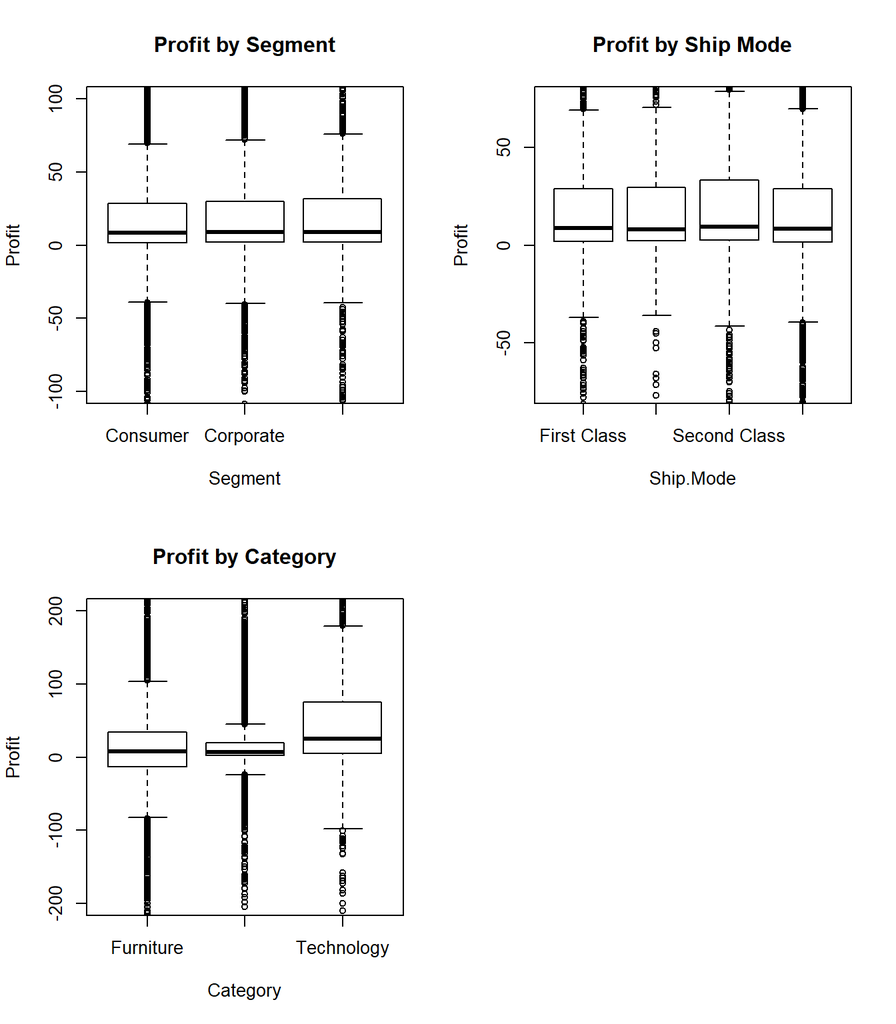

```r
par(mfrow= c(2,2))
boxplot(Profit ~ Segment, data = retail, main = "Profit by Segment", ylim = c(-100,100))
boxplot(Profit ~ Ship.Mode, retail, main = "Profit by Ship Mode", ylim =c(-75,75))
boxplot(Profit ~ Category, retail, main = "Profit by Category", ylim=c(-200,200))
```

#4. Draw a density plot for profit

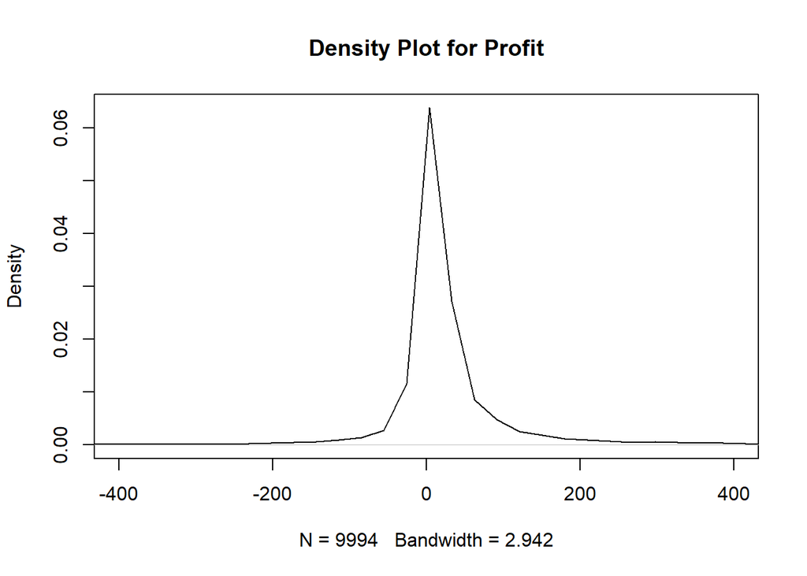

```r
plot(density(retail$Profit) , main = "Density Plot for Profit", xlim= c(-400,400))
```

#5. Carry out a one-way ANOVA to test if profit is statistically different between the segments of Consumer, Corporate and Home Office.

```r
library(car)
table(retail$Segment)
```

```
##
##    Consumer   Corporate Home Office
##        5191        3020        1783
```

```r
leveneTest(retail$Profit, retail$Segment)
```

```
## Levene's Test for Homogeneity of Variance (center = median)
##         Df F value Pr(>F)
## group    2  0.2686 0.7645
##       9991
```

**Since p-value is 0.7645 > 0.05, the variances are homogeneous. Therefore, ANOVA test can be conducted.**

```r
anova_profit <- aov(Profit ~ Segment, retail)
summary(anova_profit)
```

```
##               Df    Sum Sq Mean Sq F value Pr(>F)
## Segment        2     98570   49285   0.898  0.407
## Residuals   9991 548295266   54879
```

**Since p-value is 0.407 > 0.05, there is no statistical difference in profits between the segments of Consumer, Corporate and Home Office.**